# Act_Report: WeRateDogs Twitter

> by Kathy Mirzaei

# WeRateDogs Dataset

The "We Rate Dogs" is a Twitter account that rates people's dogs with a humorous comment about the dog. This Twitter archive contains over 5000 tweets, which have been filtered to create the enhanced archive that forms the basis of this analysis. The time frame for the posts are from November 15, 2015 to August 1, 2017.

The retweet count and favourite count for each tweet were not included in the enhanced archived at first, this data was downloaded using the twitter developer API by using the tweet id from the archive file.

In addition, the image prediction dataset was used. This data was available from Udacity and contained the top 3 predictions for a dog breed based on their image.

# Wrangling data

The data was assessed from all the three different sources, both visually and programmatically for quality and tidiness issues. The quality of the data was assessed based on the four dimentions of completeness, validity, accuracy, and consistency. The tidiness of the data was assessed based on the structure of the data. At the start point the archive had 2356 tweets, and at the final part the clean data had about 1941 clean, combined tweets.

# Insights

```python
import numpy as np
import pandas as pd
import matplotlib.pyplot as plt
import requests
import json
import tweepy
from tweepy import OAuthHandler
import os
import time
import datetime
from timeit import default_timer as timer
import seaborn as sb


%matplotlib inline

# display full string from a pandas DataFrame
pd.options.display.max_rows
pd.set_option('display.max_colwidth', -1)
```

```python
df =pd.read_csv('twitter_archive_master.csv')
```

# Distribution of Ratings:

The histogram below demonstrates that the distribution of ratings is very skewed to the left. We see that 75% of all ratings are between 10 and 14 inclusive.

- (the IQR is from 10 to 12)

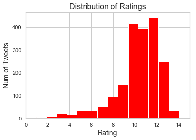

```python
df['rating'].plot(kind = 'hist', bins = 15, color='red')

plt.xlim(0, 15)
plt.title('Distribution of Ratings', fontsize = 16)
plt.ylabel('Num of Tweets', fontsize = 14)
plt.xlabel('Rating', fontsize = 14)

plt.show();
```

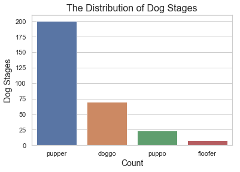

```python
sorted_stage = df['stage'].value_counts().head(3).index
sb.set(style="whitegrid")
sb.countplot(data = df, x = 'stage', order = pd.value_counts(df['stage']).iloc[1:].index, orient = 'h')
plt.xticks(rotation = 360)
plt.xlabel('Count', fontsize=14)
plt.ylabel('Dog Stages', fontsize=14)
plt.title('The Distribution of Dog Stages',fontsize=16)
```

The analysis below shows us the top 10 dog breeds based on the number of tweets it got. Top 10 dog breeds are (golden_retriever, Labrador_retriever, Pembroke, Chihuahua, pug,toy_poodle, chow,Samoyed,Pomeranian,and malamute). Top 10 dog breeds takes 37% of the total tweets.

```
Breed and number of tweets
--------------------------
golden_retriever      153
Labrador_retriever    101
Pembroke              94
Chihuahua             89
pug                   62
toy_poodle            49
chow                  47
Samoyed               41
Pomeranian            40
malamute              33
Name: breed, dtype: int64

Top 10 dog breeds make up 37% of all tweets
```

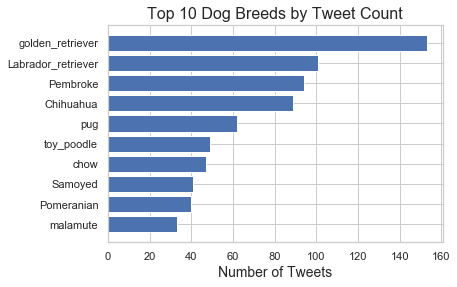

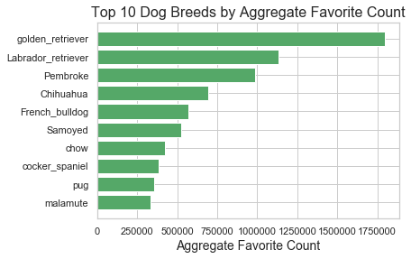

```python
top10_breeds_count = \
df[df.breed != 'none'].breed.value_counts().head(10)
print("Breed and number of tweets")
print("--------------------------")
print(top10_breeds_count)

top10_per = round(sum(top10_breeds_count) * 100 / df.shape[0])
print("\nTop 10 dog breeds make up {}% of all tweets".format(top10_per))
plt.barh(top10_breeds_count.index, top10_breeds_count)

plt.xlabel('Number of Tweets', fontsize = 14)
# plt.ylabel('Dog Breed', fontsize = 14)
plt.title('Top 10 Dog Breeds by Tweet Count', fontsize = 16)
plt.gca().invert_yaxis()
plt.show();

#highest overal favorite counts
fav_counts_breed = df[df.breed != 'none']
fav_counts_breed = fav_counts_breed.groupby(['breed'])
fav_counts_breed = fav_counts_breed['favorite_count'].sum()
fav_counts_breed = fav_counts_breed.sort_values(ascending = False)
top10_breeds_fav_counts = fav_counts_breed.head(10)
top10_breeds_fav_counts

plt.barh(top10_breeds_fav_counts.index, top10_breeds_fav_counts, color = 'g')
plt.xlabel('Aggregate Favorite Count', fontsize = 14)
# plt.ylabel('Dog Breed', fontsize = 12)
plt.title('Top 10 Dog Breeds by Aggregate Favorite Count', fontsize = 16)
plt.gca().invert_yaxis()
plt.show();
```

### Strong relationship between Favourite Count and Retweet Count:

In the below plot you will see a strong relationship between retweet counts and favourite counts. The higher the favourite count is, the more re-tweet it gets. The plot below demonstrates a strong positive correlation between the two variables.

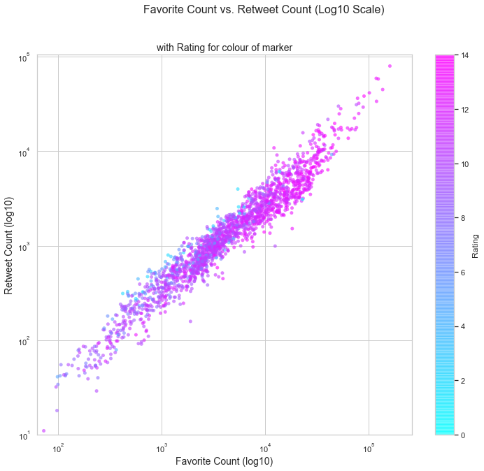

```python
cmap = plt.cm.get_cmap('cool') # Colour map (there are many others)
plt.figure(figsize = (12, 10))

plt.xscale('log')
plt.yscale('log')
plt.xlim(df['favorite_count'].min() - 10, df['favorite_count'].max() + 100000)
plt.ylim(10, df['retweet_count'].max() + 25000)
colours = df['rating']
markers = 25

plt.scatter(df['favorite_count'], df['retweet_count'],
            c = colours, s = markers, cmap = cmap, edgecolor = 'None', alpha = 0.6)

# title and labels
plt.suptitle('Favorite Count vs. Retweet Count (Log10 Scale)', fontsize = 16)
plt.title('with Rating for colour of marker', fontsize = 14)
plt.xlabel('Favorite Count (log10)', fontsize = 14)
plt.ylabel('Retweet Count (log10)', fontsize = 14)

# colour bar
cbar = plt.colorbar()
cbar.set_label('Rating')

plt.show();
```

### Higher ratings = higher re-tweets and higher favourites

The colors added to each tweet denotes the rating blue is lower, and purple is higher. It is noticable that there are many more purple than blues which shos the facourite counts and retweet counts are higher in number. There is also a lot of mid-level ratings that fall in between the two spectrums. This makes sense as a tweet would be retweeted and favoured if the dog is remarkable in some sort of a way!

### Insights summary:

- Distribution of ratings is skewed to the the left, 75% of all ratings falls between 10-14
- 79% of tweets has a rating of 10 or higher
- Pupper has the highest dog stage distribution
- There are 113 distinct breeds of dog and 302 unpredicted breeds in the data
- Top 10 dog breeds are (golden_retriever, Labrador_retriever, Pembroke, Chihuahua, pug,toy_poodle, chow,Samoyed,Pomeranian,and malamute)
- Top 10 dog breeds take 37% of total tweets.
- There is a strong correlation between re-tweet counts and favourite counts.
- In the above plot we can see a strong positive correlation between retweet counts and favorite counts. Align with this is that the high favorite counts and high retweets have higher dog ratings as well.